# Ejercicios 7

Nícolas Farfán Cheneaux

2022-07-10

#### 1.- Cree su propio ejemplo de regresión lineal simple utilizando un conjunto de datos con dos variables y la función lm. Grafique utilizando las funciones plot y abline.

Utilizando un archivo de texto data.csv que contiene información sobre el tiempo de duración de las sesiones de hemodiálisis (meses) y número de quistes en pacientes hospitalarios. ¿Existe alguna relación entre el tiempo y el número de quistes?

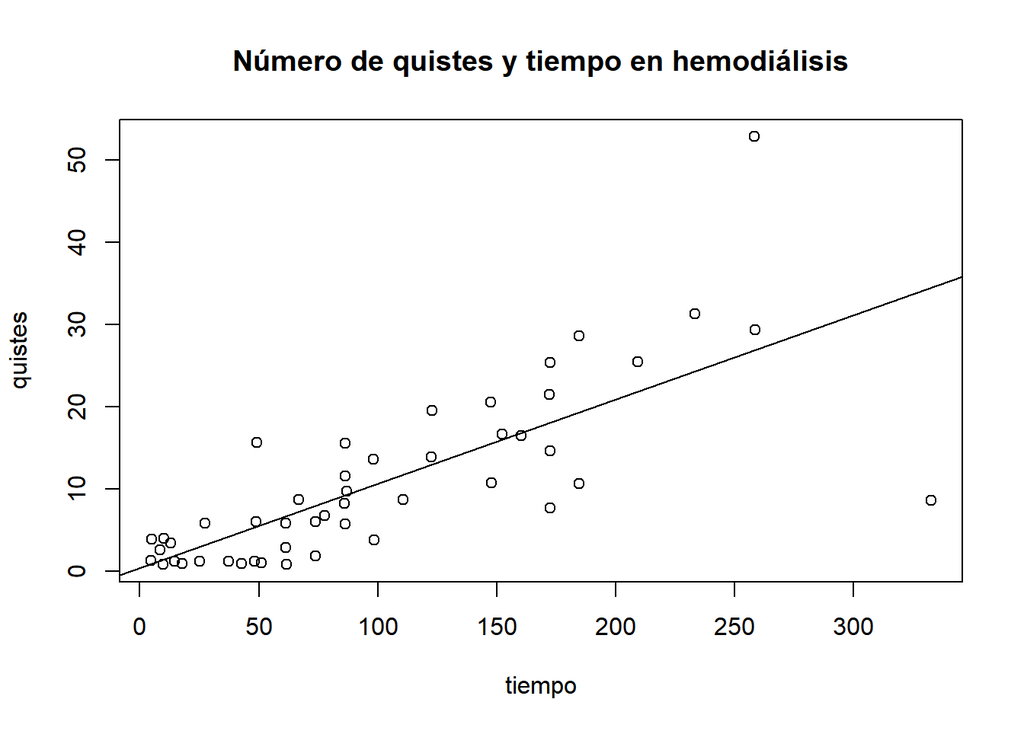

```r
library("ggplot2")
datos = read.csv2(file = "data.csv")

tiempo = as.numeric(datos$Tiempo)
quistes = as.numeric(datos$Quistes)
mod = lm(quistes ~ tiempo, datos)
plot(tiempo, quistes)
title("Número de quistes y tiempo en hemodiálisis")
abline(mod)
```

Podemos obtener mas informacion del modelo construido:

```r
summary(mod)
```

```
##
## Call:
## lm(formula = quistes ~ tiempo, data = datos)
##
## Residuals:
##      Min       1Q   Median       3Q      Max
## -25.8814  -3.4532   0.0344   2.6901  25.9934
##
## Coefficients:
##             Estimate Std. Error t value Pr(>|t|)
## (Intercept)  0.41550    1.67406   0.248    0.805
## tiempo       0.10244    0.01323   7.742 7.11e-10 ***
## ---
## Signif. codes:  0 '***' 0.001 '**' 0.01 '*' 0.05 '.' 0.1 ' ' 1
##
## Residual standard error: 7.026 on 46 degrees of freedom
## Multiple R-squared:  0.5658, Adjusted R-squared:  0.5564
## F-statistic: 59.95 on 1 and 46 DF,  p-value: 7.107e-10
```

Uno de los datos importantes es el **coeficiente de determinación**

```r
print(summary(mod)$r.squared)
```

```
## [1] 0.5658145
```

```r
confianza = confint(mod, level = 0.95)
print(confianza)
```

```
##                  2.5 %    97.5 %
## (Intercept) -2.9541954 3.7852028
## tiempo       0.0758044 0.1290673
```

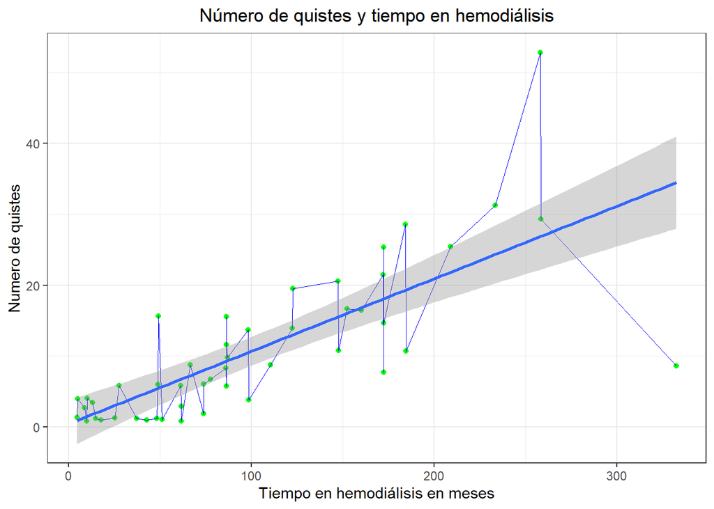

```r
grafico = ggplot(datos,aes(x=tiempo, y=quistes, label= "")) +
  geom_point(aes(tiempo,quistes),datos,color = "green")+
  theme_bw() + ylab("Numero de quistes")+
  xlab("Tiempo en hemodiálisis en meses") + ggtitle("Número de quistes y tiempo en hemodiálisis") +
  theme(plot.title = element_text(hjust = 0.5)) +
  geom_text(check_overlap = TRUE) +
  geom_line(aes(tiempo,quistes),datos,color="blue",cex=0.1) +
  geom_smooth(method ="lm", formula = y ~ x,level=0.95)
plot(grafico)
```

De lo anterior, **podemos concluir** que utilizando un nivel de confianza del 95% **si existe una relación entre tiempo y el número de quistes.** Si es directa o no va a depender bien del tiempo, ya que puede variar en algunos casos, pero generalmente tiende a ser directa. Sin embargo, el **modelo propuesto no es el adecuado para todos los puntos de datos** ya que el coeficiente de determinación no se acerca a 0,99, e incluso con zonas de confianza se puede observar que varios puntos quedan fuera de estas zonas.

#### 2.- Utilice el modelo de regresión lineal simple de la actividad 1 para predecir 5 nuevos registros e incorpórelos a su conjunto de datos. Calcule nuevamente la regresión lineal simple ¿Se observa algún cambio en los coeficientes?

```r
df = data.frame(tiempo,quistes)
tiempo = c(4,5,8,9,10)
predict.lm(mod, data.frame(tiempo = tiempo))
```

```
##         1         2         3         4         5
## 0.8252472 0.9276830 1.2349906 1.3374264 1.4398623
```

```r
quistes = c(0.8252472,0.9276830,1.2349906,1.3374264,1.4398623)
df2 = data.frame(tiempo = tiempo, quistes = quistes)
df3 = rbind(df,df2)

tiempo = df3$tiempo
quistes = df3$quistes
```

Ahora, volvemos a realizar toda la regresión lineal simple:

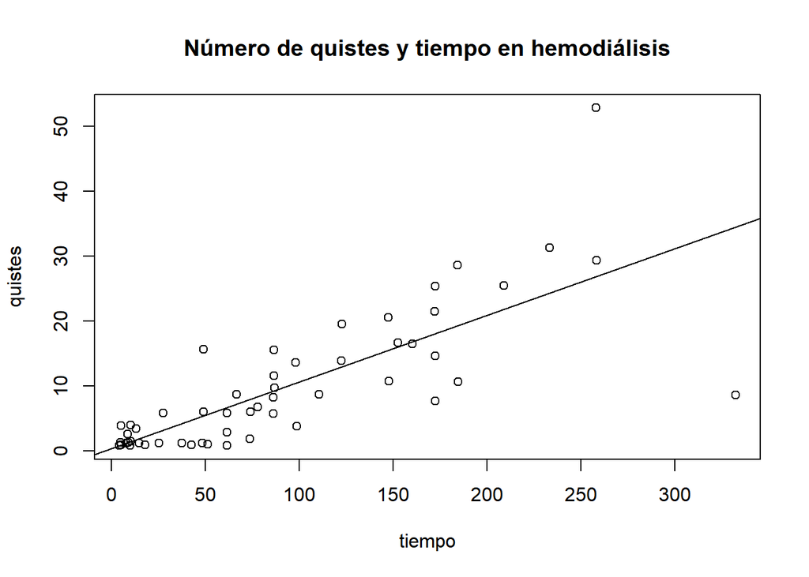

```r
mod = lm(quistes ~ tiempo, df3)
plot(tiempo, quistes)
title("Número de quistes y tiempo en hemodiálisis")
abline(mod)
```

Podemos obtener mas informacion del modelo construido:

```r
summary(mod)
```

```
##
## Call:
## lm(formula = quistes ~ tiempo, data = df3)
##
## Residuals:
##     Min      1Q  Median      3Q     Max
## -25.881  -3.033   0.000   2.565  25.993
##
## Coefficients:
##             Estimate Std. Error t value Pr(>|t|)
## (Intercept)  0.41550    1.41711   0.293    0.771
## tiempo       0.10244    0.01177   8.706 1.17e-11 ***
## ---
## Signif. codes:  0 '***' 0.001 '**' 0.01 '*' 0.05 '.' 0.1 ' ' 1
##
## Residual standard error: 6.673 on 51 degrees of freedom
## Multiple R-squared:  0.5978, Adjusted R-squared:  0.5899
## F-statistic: 75.79 on 1 and 51 DF,  p-value: 1.166e-11
```

Uno de los datos importantes es el **coeficiente de determinación**

```r
print(summary(mod)$r.squared)
```

```
## [1] 0.5977625
```

Si observamos los p-values, solo el del intercepto es mayor a 0,05. Por lo tanto:

- **Se acepta la hipótesis Nula de que el intercepto no es representativo y vale 0.**
- **Se rechaza la hipótesis Nula de que la pendiente de la recta es 0**

```r
confianza = confint(mod, level = 0.95)
print(confianza)
```

```
##                   2.5 %    97.5 %
## (Intercept) -2.42946338 3.2604708
## tiempo       0.07881381 0.1260579
```

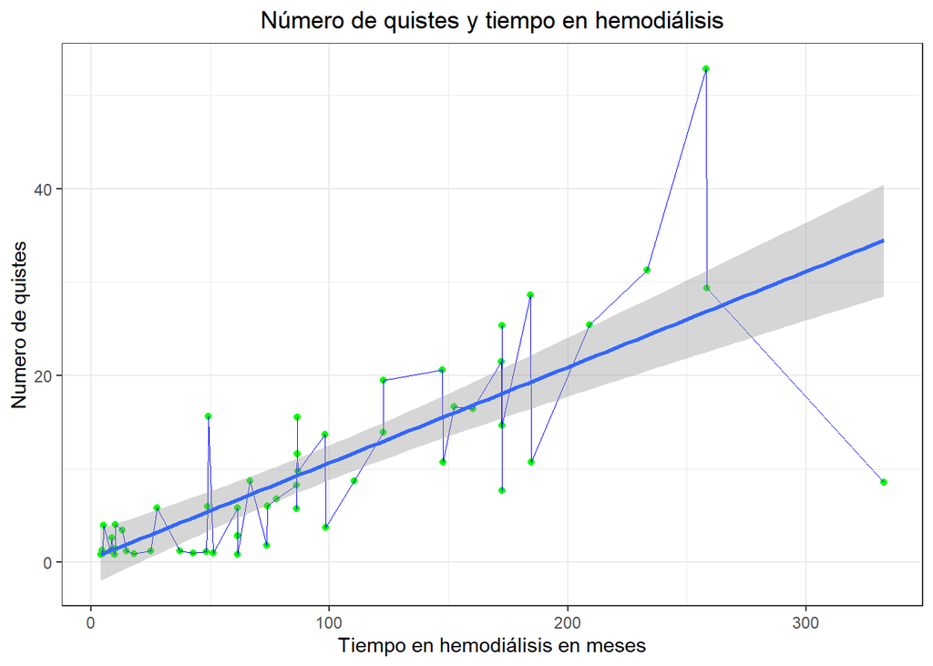

```r
grafico = ggplot(df3,aes(x=tiempo, y=quistes, label= "")) +
  geom_point(aes(tiempo,quistes),df3,color = "green")+
  theme_bw() + ylab("Numero de quistes")+
  xlab("Tiempo en hemodiálisis en meses") + ggtitle("Número de quistes y tiempo en hemodiálisis") +
  theme(plot.title = element_text(hjust = 0.5)) +
  geom_text(check_overlap = TRUE) +
  geom_line(aes(tiempo,quistes),df3,color="blue",cex=0.1) +
  geom_smooth(method ="lm", formula = y ~ x,level=0.95)
plot(grafico)
```

De lo anterior, **podemos concluir** que utilizando un nivel de confianza del 95% **todavia existe una relación entre tiempo y el número de quistes.** Si es directa o no va a depender bien del tiempo, ya que puede variar en algunos casos, pero generalmente tiende a ser directa. Sin embargo, el **modelo propuesto sigue siendo un modelo no adecuado para todos los puntos de datos** ya que el coeficiente de determinación no se acerca a 0,99, e incluso con zonas de confianza se puede observar que varios puntos quedan fuera de estas zonas.

#### 3.- Tome un punto cualquiera de su conjunto de datos y multiplíquelo por 100, calcule nuevamente la regresión lineal simple ¿Se observa algún cambio en los coeficientes?

```r
datos = read.csv2(file = "data.csv")
tiempo = as.numeric(datos$Tiempo)
quistes = as.numeric(datos$Quistes)

df = data.frame(tiempo, quistes)
df2 = data.frame(tiempo = 10*100, quistes = 0.8 * 100)
df = rbind(df, df2)
tiempo = df$tiempo
quistes = df$quistes
```

Ahora, volvemos a realizar toda la regresión lineal simple

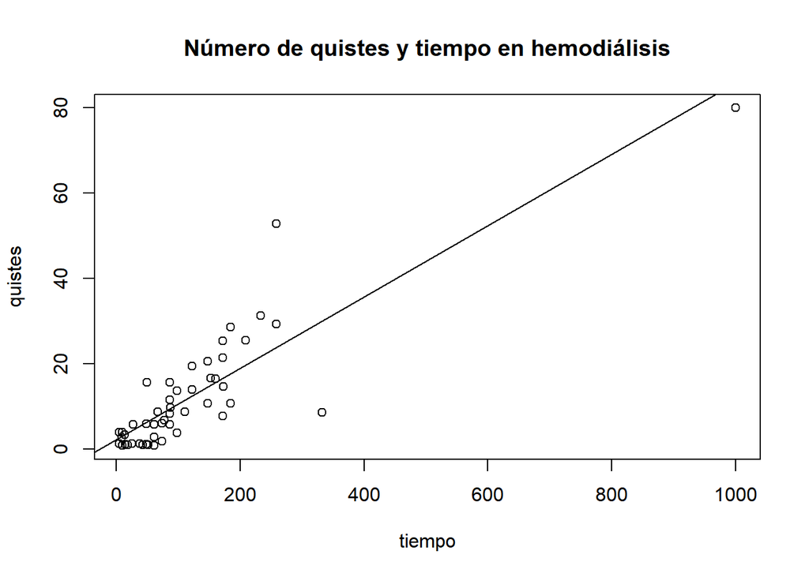

```r
mod = lm(quistes ~ tiempo, df)
plot(tiempo, quistes)
title("Número de quistes y tiempo en hemodiálisis")
abline(mod)
```

Podemos obtener mas informacion del modelo construido:

```r
summary(mod)
```

```
##
## Call:
## lm(formula = quistes ~ tiempo, data = df)
##
## Residuals:
##     Min      1Q  Median      3Q     Max
## -21.415  -3.819  -1.126   2.163  29.067
##
## Coefficients:
##             Estimate Std. Error t value Pr(>|t|)
## (Intercept) 2.179529   1.311174   1.662    0.103
## tiempo      0.083697   0.006902  12.127 4.45e-16 ***
## ---
## Signif. codes:  0 '***' 0.001 '**' 0.01 '*' 0.05 '.' 0.1 ' ' 1
##
## Residual standard error: 7.154 on 47 degrees of freedom
## Multiple R-squared:  0.7578, Adjusted R-squared:  0.7527
## F-statistic: 147.1 on 1 and 47 DF,  p-value: 4.453e-16
```

Uno de los datos importantes es el **coeficiente de determinación**

```r
print(summary(mod)$r.squared)
```

```
## [1] 0.7578103
```

Si observamos los p-values, el del intercepto es mayor a 0,05, pero el de tiempo es muy bajo. Por lo tanto:

- **Se acepta la hipótesis Nula de que el intercepto no es representativo y vale 0.**
- **Se rechaza la hipótesis Nula de que la pendiente de la recta es 0**

Finalmente, podemos generar una zona de confianza para ver que puntos estan representados por el modelo generado

```r
confianza = confint(mod, level = 0.95)
print(confianza)
```

```
##                   2.5 %     97.5 %
## (Intercept) -0.45821343 4.81727165
## tiempo       0.06981243 0.09758142
```

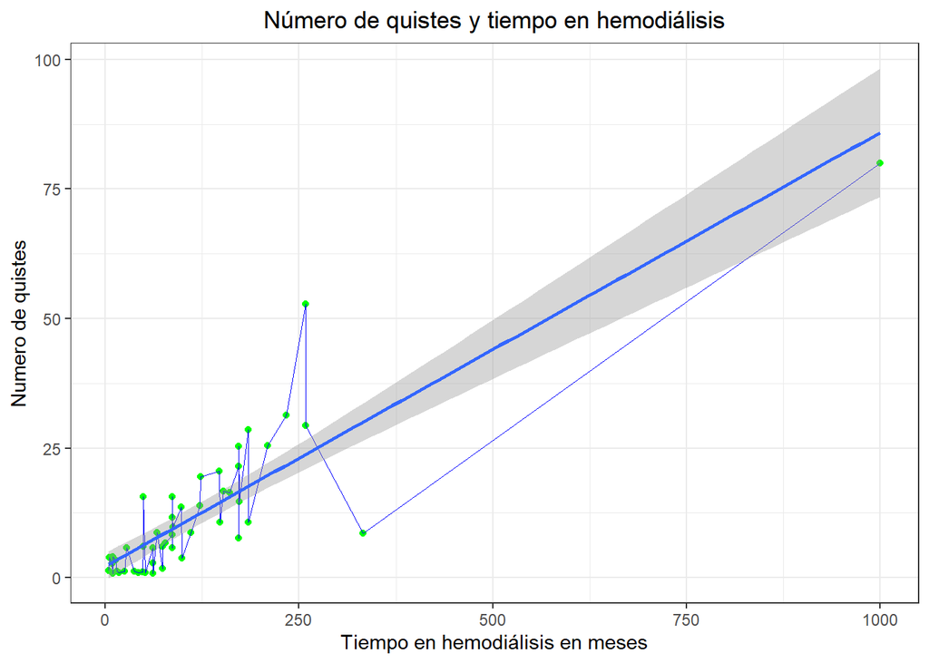

```r
grafico = ggplot(df,aes(x=tiempo, y=quistes, label= "")) +
  geom_point(aes(tiempo,quistes),df,color = "green")+
  theme_bw() + ylab("Numero de quistes")+
  xlab("Tiempo en hemodiálisis en meses") + ggtitle("Número de quistes y tiempo en hemodiálisis") +
  theme(plot.title = element_text(hjust = 0.5)) +
  geom_text(check_overlap = TRUE) +
  geom_line(aes(tiempo,quistes),df,color="blue",cex=0.1) +
  geom_smooth(method ="lm", formula = y ~ x,level=0.95)
plot(grafico)
```

De lo anterior, se concluye que utilizando un nivel de confianza del 95% todavia existe una relación entre tiempo y el número de quistes. Si es directa o no va a depender bien del tiempo, ya que puede variar en algunos casos, sin embargo tiende a ser directa. No obstante el modelo propuesto sigue siendo un modelo no adecuado para todos los puntos de datos, ya que el coeficiente de determinación no se acerca a 0,99, e incluso con zonas de confianza se puede observar que varios puntos quedan fuera de estas zonas.